# Homework 6

Hyunjoon Rhee

5/3/2021

## Problem 1

### a)

```r
library(faraway)
attach(butterfat)
```

```r
head(butterfat)
```

|  | Butterfat | Breed | Age |
| --- | --- | --- | --- |
| 1 | 3.74 | Ayrshire | Mature |
| 2 | 4.01 | Ayrshire | 2year |
| 3 | 3.77 | Ayrshire | Mature |
| 4 | 3.78 | Ayrshire | 2year |
| 5 | 4.10 | Ayrshire | Mature |
| 6 | 4.06 | Ayrshire | 2year |

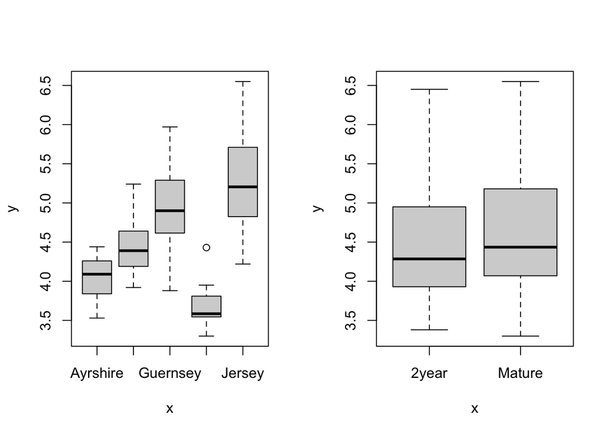

```r
par(mfrow=c(1,2))
plot(Breed, Butterfat, data = butterfat)
plot(Age, Butterfat, data = butterfat)
```

### b)

```r
model=aov(Butterfat~Breed+Age+Breed*Age, data = butterfat)
summary(model)
```

```
##             Df Sum Sq Mean Sq F value Pr(>F)
## Breed        4  34.32   8.580  49.565 <2e-16 ***
## Age          1   0.27   0.274   1.580  0.212
## Breed:Age    4   0.51   0.128   0.742  0.566
## Residuals   90  15.58   0.173
## ---
## Signif. codes:  0 '***' 0.001 '**' 0.01 '*' 0.05 '.' 0.1 ' ' 1
```

Because the p value for breed and age interaction term is greater than $\alpha = 0.05$ which means that it fails to reject that there is an interaction term has zero effect on the response.

### c)

```r
maineffect = lm(Butterfat ~ Breed + Age, data = butterfat)
summary(maineffect)
```

```
##
## Call:
## lm(formula = Butterfat ~ Breed + Age, data = butterfat)
##
## Residuals:
##     Min      1Q  Median      3Q     Max
## -1.0202 -0.2373 -0.0640  0.2617  1.2098
##
## Coefficients:
##                       Estimate Std. Error t value Pr(>|t|)
## (Intercept)            4.00770    0.10135  39.541  < 2e-16 ***
## BreedCanadian          0.37850    0.13085   2.893  0.00475 **
## BreedGuernsey          0.89000    0.13085   6.802 9.48e-10 ***
## BreedHolstein-Fresian -0.39050    0.13085  -2.984  0.00362 **
## BreedJersey            1.23250    0.13085   9.419 3.16e-15 ***
## AgeMature              0.10460    0.08276   1.264  0.20937
## ---
## Signif. codes:  0 '***' 0.001 '**' 0.01 '*' 0.05 '.' 0.1 ' ' 1
##
## Residual standard error: 0.4138 on 94 degrees of freedom
## Multiple R-squared:  0.6825, Adjusted R-squared:  0.6656
## F-statistic: 40.41 on 5 and 94 DF,  p-value: < 2.2e-16
```

```r
anova(lm(Butterfat ~ Breed, data=butterfat))
```

|  | Df | Sum Sq | Mean Sq | F value | Pr(>F) |
| --- | --- | --- | --- | --- | --- |
| Breed | 4 | 34.32133 | 8.5803335 | 49.80177 | 1.590346e-22 |
| Residuals | 95 | 16.36753 | 0.1722897 | NA | NA |

```r
anova(lm(Butterfat ~ Age, data=butterfat))
```

|  | Df | Sum Sq | Mean Sq | F value | Pr(>F) |
| --- | --- | --- | --- | --- | --- |
| Age | 1 | 0.273529 | 0.2735290 | 0.5317002 | 0.4676321 |
| Residuals | 98 | 50.415330 | 0.5144421 | NA | NA |

Looking at the anova table of the two of the p values, it is evident that there is a statistical difference between the breed and the butterfat, whereas age does not have statistical difference between age and butterfat. This is the same result as the above analysis.

### d)

Constant variance check

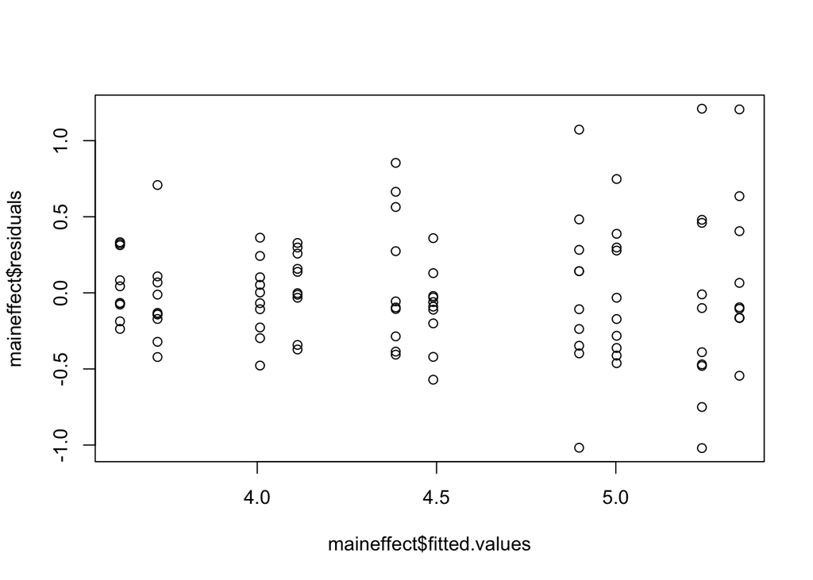

```r
plot(maineffect$fitted.values, maineffect$residuals)
```

```r
library(lmtest)
bptest(maineffect)
```

```
##
##  studentized Breusch-Pagan test
##
## data:  maineffect
## BP = 14.739, df = 5, p-value = 0.01154
```

It is hard to see from the graph if there is a constant variance, so Breusch-Pagan test was performed. The bptest shows a p value that is less than $\alpha = 0.05$, which means it can reject the null hypothesis and conclude that it is not homoskedastic.

Normality check

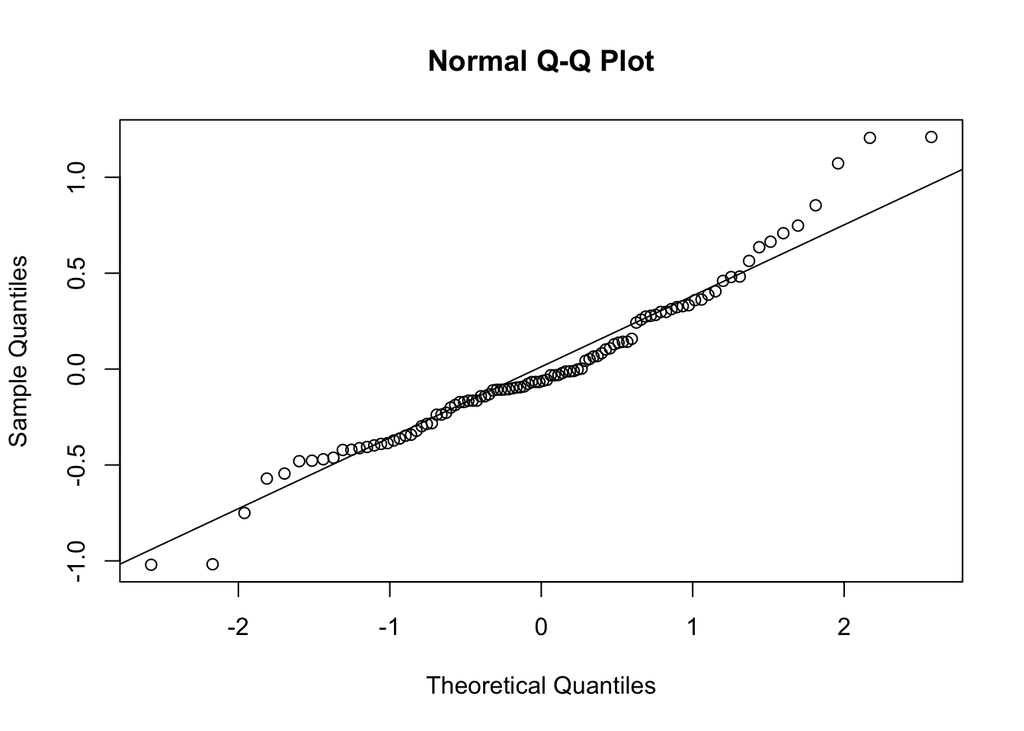

```r
qqnorm(maineffect$residuals)
qqline(maineffect$residuals)
```

```r
shapiro.test(maineffect$residuals)
```

```
##
##  Shapiro-Wilk normality test
##
## data:  maineffect$residuals
## W = 0.96347, p-value = 0.007168
```

The qqplot seems to show a straight line, but for further analysis, shapiro-wilk test was performed. Because the p value is smaller than $\alpha=0.05$, it is evident that it can reject the null hypothesis and conclude that the residual is not normally distributed.

```r
dwtest(maineffect)
```

```
##
##  Durbin-Watson test
##
## data:  maineffect
## DW = 2.0367, p-value = 0.4531
## alternative hypothesis: true autocorrelation is greater than 0
```

The Durbin-Watson test shows it has a p value that is greater than $\alpha=0.05$, which means that it fails to reject the null hypothesis and conclude that the errors are statistically not correlated.

### e)

```r
library(tidyverse)
bestbreed = butterfat %>% filter(Breed == 'Jersey' | Breed == 'Guernsey') %>% select(Butterfat, Breed)
t.test(Butterfat ~ Breed, data = bestbreed)
```

```
##
##  Welch Two Sample t-test
##
## data:  Butterfat by Breed
## t = -1.9895, df = 36.367, p-value = 0.05421
## alternative hypothesis: true difference in means is not equal to 0
## 95 percent confidence interval:
##  -0.691530171  0.006530171
## sample estimates:
## mean in group Guernsey   mean in group Jersey
##                 4.9500                 5.2925
```

Looking at the results in Problem 1 a), it is known that Jersey and Guernsey are the two breeds that has most butterfat content. Because the p value of the t test is greater than $\alpha=0.05$, it fails to reject the null hypothesis and conclude that it is hard to say there is a statistical difference between the best and the second.

## Problem 2

### a)

```r
anova(lm(Speed ~ Run + Expt, data = morley))
```

|  | Df | Sum Sq | Mean Sq | F value | Pr(>F) |
| --- | --- | --- | --- | --- | --- |
| Run | 1 | 411.6992 | 411.6992 | 0.07327064 | 0.787208074 |
| Expt | 1 | 72580.5000 | 72580.5000 | 12.91724353 | 0.000513792 |
| Residuals | 97 | 545031.8008 | 5618.8845 | NA | NA |

```r
anova(lm(Speed ~ Run, data = morley))
```

|  | Df | Sum Sq | Mean Sq | F value | Pr(>F) |
| --- | --- | --- | --- | --- | --- |
| Run | 1 | 411.6992 | 411.6992 | 0.06532662 | 0.7988026 |
| Residuals | 98 | 617612.3008 | 6302.1663 | NA | NA |

Looking at the p value of the anova table, it is much greater than $\alpha=0.05$, which means that there is not a significant difference among the run groups.

### b)

By using blocking factor, it can categorize the difference between the run groups and compare the response. Without a blocking factor, it would have not earned any meaningful data related to the mean of the speed.

## Problem 3

### a)

```r
prob3 = lm(yield~ ., alfalfa)
anova(prob3)
```

|  | Df | Sum Sq | Mean Sq | F value | Pr(>F) |
| --- | --- | --- | --- | --- | --- |
| shade | 4 | 87.4024 | 21.8506 | 7.125351 | 0.0035328694 |
| irrigation | 4 | 16.5624 | 4.1406 | 1.350225 | 0.3078717042 |
| inoculum | 4 | 155.8944 | 38.9736 | 12.709059 | 0.0002839824 |
| Residuals | 12 | 36.7992 | 3.0666 | NA | NA |

The anova table shows that when the $\alpha=0.05$, shade and inoculum show statistical significance whereas irrigation does not.

### b)

```r
TukeyHSD(aov(yield~., alfalfa), "inoculum")
```

```
##   Tukey multiple comparisons of means
##     95% family-wise confidence level
##
## Fit: aov(formula = yield ~ ., data = alfalfa)
##
## $inoculum
##      diff        lwr       upr     p adj
## B-A -0.72  -4.250202  2.810202 0.9633433
## C-A -0.08  -3.610202  3.450202 0.9999928
## D-A -0.86  -4.390202  2.670202 0.9326392
## E-A -6.60 -10.130202 -3.069798 0.0005166
## C-B  0.64  -2.890202  4.170202 0.9759059
## D-B -0.14  -3.670202  3.390202 0.9999332
## E-B -5.88  -9.410202 -2.349798 0.0014163
## D-C -0.78  -4.310202  2.750202 0.9515868
## E-C -6.52 -10.050202 -2.989798 0.0005764
## E-D -5.74  -9.270202 -2.209798 0.0017334
```